## Demand Forecasting Using Time Series Modeling: Case Study

### Background: In manufacturing sector, many decisions are taken based on forecasting future demand. The demand forecasting helps companies to manage accurate, timely and effective production. The sports goods manufacturing company identified 3 top products for which demand forecasting was most critical. The 5-years monthly sales data for 3 products was used to develop the model.

### Objective: Forecast next 3 months sales using trend and seasonality exhibited over 5 years of sales data.

#### Import data and display first 6 rows

```r
salesdata<-read.csv("PRODUCT SALES DATA.csv",header = T)
head(salesdata)
```

```
  Year    Month Product1 Product2 Product3
1 2014  January   123.57   118.69   120.51
2 2014 February   122.31   120.07   115.83
3 2014    March   123.20   119.84   115.44
4 2014    April   123.47   119.41   118.30
5 2014      May   127.16   119.57   128.64
6 2014     June   131.29   118.56   113.22
```

#### Data Description

| Column name | Column description |
| --- | --- |
| Year | Year of sales |
| Month | Month of sales |
| Product1.Product2.Product3 | Product sales (USD '000) |

#### Analysis of Product 1

#### Create a time series object and visualize sales over 5 years

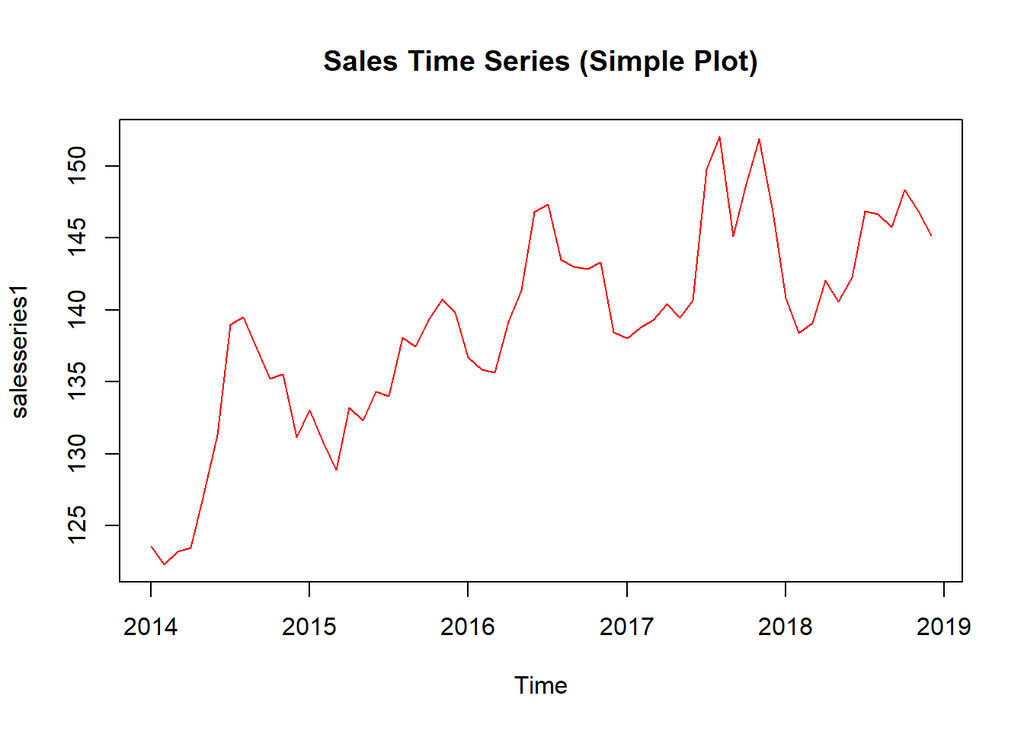

```r
salesseries1<-ts(salesdata$Product1,start=c(2014,1),end=c(2018,12),
                frequency=12)

plot(salesseries1,col="red",main="Sales Time Series (Simple Plot)")
```

#### Display ACF plot to check if product 1 sales forms stationary time series

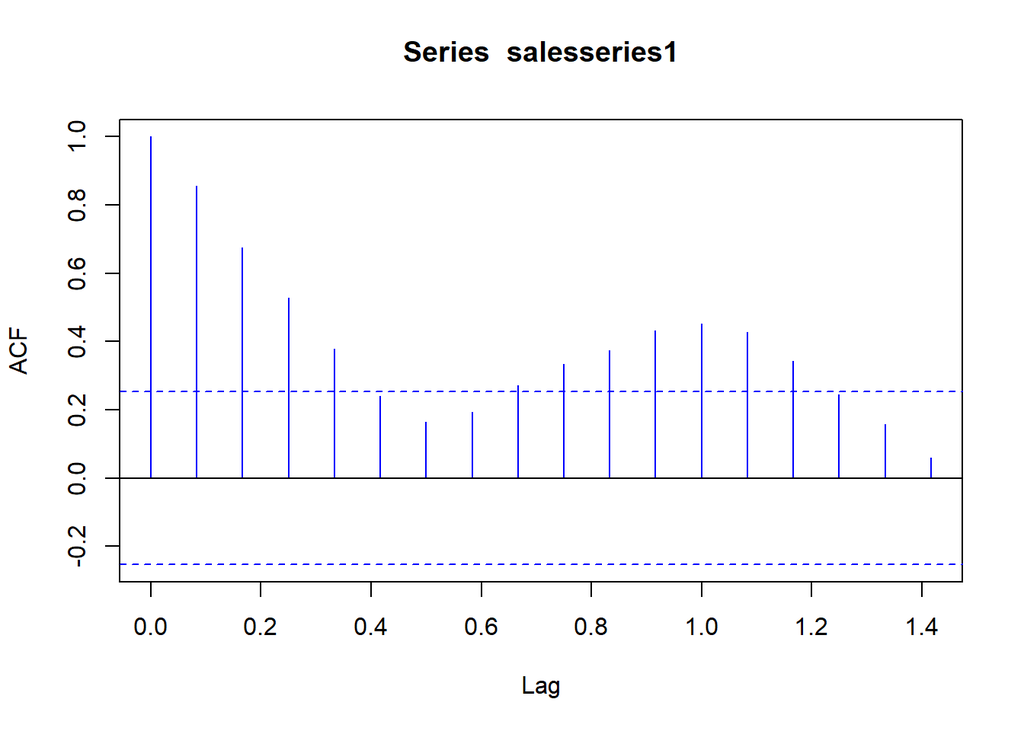

```r
acf(salesseries1,col="blue")
```

#### ACF plot shows a slow decay indicating non-stationarity

#### Dickey-Fuller test for product 1 time series

```r
library(urca)

df1<-ur.df(salesseries1, lag=0)
summary(df1)
```

```
###############################################
# Augmented Dickey-Fuller Test Unit Root Test #
###############################################

Test regression none


Call:
lm(formula = z.diff ~ z.lag.1 - 1)

Residuals:
    Min      1Q  Median      3Q     Max
-7.2601 -1.6758 -0.0015  1.7873  8.7861

Coefficients:
        Estimate Std. Error t value Pr(>|t|)
z.lag.1 0.002303   0.002885   0.798    0.428

Residual standard error: 3.081 on 58 degrees of freedom
Multiple R-squared:  0.01087,   Adjusted R-squared:  -0.006183
F-statistic: 0.6374 on 1 and 58 DF,  p-value: 0.4279


Value of test-statistic is: 0.7984

Critical values for test statistics:
     1pct  5pct 10pct
tau1 -2.6 -1.95 -1.61
```

#### Value of test statistic is greater than 5% critical value. Hence, Time series is non-stationary.

#### Dickey-Fuller test for 1st order differenced time series

```r
salesdiff1 <- diff(salesseries1,differences = 1)
summary(ur.df(salesdiff1,lags = 0))
```

```
###############################################
# Augmented Dickey-Fuller Test Unit Root Test #
###############################################

Test regression none


Call:
lm(formula = z.diff ~ z.lag.1 - 1)

Residuals:
    Min      1Q  Median      3Q     Max
-7.2297 -1.5281  0.2037  2.1021  8.9388

Coefficients:
        Estimate Std. Error t value Pr(>|t|)
z.lag.1  -0.8585     0.1313  -6.541 1.85e-08 ***
---
Signif. codes:  0 '***' 0.001 '**' 0.01 '*' 0.05 '.' 0.1 ' ' 1

Residual standard error: 3.089 on 57 degrees of freedom
Multiple R-squared:  0.4288,    Adjusted R-squared:  0.4187
F-statistic: 42.78 on 1 and 57 DF,  p-value: 1.845e-08


Value of test-statistic is: -6.5408

Critical values for test statistics:
     1pct  5pct 10pct
tau1 -2.6 -1.95 -1.61
```

#### Value of test statistic is less than 5% critical value. Hence, Time series is stationary.

#### Automatic Model Identification and Parameter Estimation

```r
library(forecast)

auto.arima(salesseries1,d=1,D=1,max.p=2,max.q=2,max.P=2,max.Q=2,
           trace=TRUE,ic="aic")
```

```
 ARIMA(2,1,2)(1,1,1)[12]                    : Inf
 ARIMA(0,1,0)(0,1,0)[12]                    : 259.3857
 ARIMA(1,1,0)(1,1,0)[12]                    : 246.0024
 ARIMA(0,1,1)(0,1,1)[12]                    : Inf
 ARIMA(1,1,0)(0,1,0)[12]                    : 261.0493
 ARIMA(1,1,0)(1,1,1)[12]                    : Inf
 ARIMA(1,1,0)(0,1,1)[12]                    : Inf
 ARIMA(0,1,0)(1,1,0)[12]                    : 244.1962
 ARIMA(0,1,0)(1,1,1)[12]                    : Inf
 ARIMA(0,1,0)(0,1,1)[12]                    : Inf
 ARIMA(0,1,1)(1,1,0)[12]                    : 245.7811
 ARIMA(1,1,1)(1,1,0)[12]                    : 244.5898

 Best model: ARIMA(0,1,0)(1,1,0)[12]
```

```
Series: salesseries1
ARIMA(0,1,0)(1,1,0)[12]

Coefficients:
         sar1
      -0.6188
s.e.   0.1148

sigma^2 = 8.771:  log likelihood = -120.1
AIC=244.2   AICc=244.47   BIC=247.9
```

#### Store auto.arima in object salesmodel1 and then get coefficients

```r
salesmodel1<-auto.arima(salesseries1,d=1,D=1,max.p=2,max.q=2,max.P=2,max.Q=2,
           trace=TRUE,ic="aic")
```

```
 ARIMA(2,1,2)(1,1,1)[12]                    : Inf
 ARIMA(0,1,0)(0,1,0)[12]                    : 259.3857
 ARIMA(1,1,0)(1,1,0)[12]                    : 246.0024
 ARIMA(0,1,1)(0,1,1)[12]                    : Inf
 ARIMA(1,1,0)(0,1,0)[12]                    : 261.0493
 ARIMA(1,1,0)(1,1,1)[12]                    : Inf
 ARIMA(1,1,0)(0,1,1)[12]                    : Inf
 ARIMA(0,1,0)(1,1,0)[12]                    : 244.1962
 ARIMA(0,1,0)(1,1,1)[12]                    : Inf
 ARIMA(0,1,0)(0,1,1)[12]                    : Inf
 ARIMA(0,1,1)(1,1,0)[12]                    : 245.7811
 ARIMA(1,1,1)(1,1,0)[12]                    : 244.5898

 Best model: ARIMA(0,1,0)(1,1,0)[12]
```

```r
coef(salesmodel1)
```

```
      sar1
-0.6187931
```

#### Check if residuals are white noise using Box-Pierce Test

```r
resi1<-residuals(salesmodel1)
Box.test(resi1)
```

```
    Box-Pierce test

data:  resi1
X-squared = 0.26426, df = 1, p-value = 0.6072
```

#### Since p-value is greater than 0.05, do not reject Ho. Hence it can be concluded that errors follow white noise process

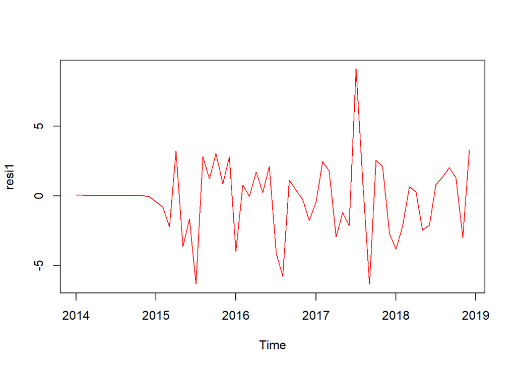

```r
plot(resi1,col="red")
```

#### Forecast product 1 sales for the next 3 months

```r
predict(salesmodel1,n.ahead=3)
```

```
$pred
          Jan      Feb      Mar
2019 142.6657 142.1735 142.7697

$se
          Jan      Feb      Mar
2019 2.961521 4.188223 5.129505
```

#### Analysis of Product 2

#### Create a time series object and visualize sales over 5 years

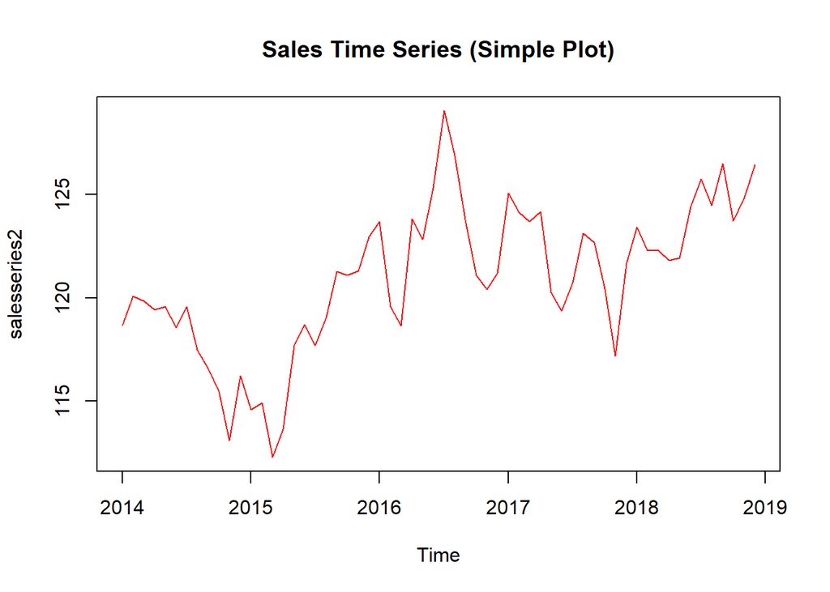

```r
salesseries2<-ts(salesdata$Product2,start=c(2014,1),end=c(2018,12),
                frequency=12)

plot(salesseries2,col="red",main="Sales Time Series (Simple Plot)")
```

#### Display ACF plot to check if product 2 sales forms stationary time series

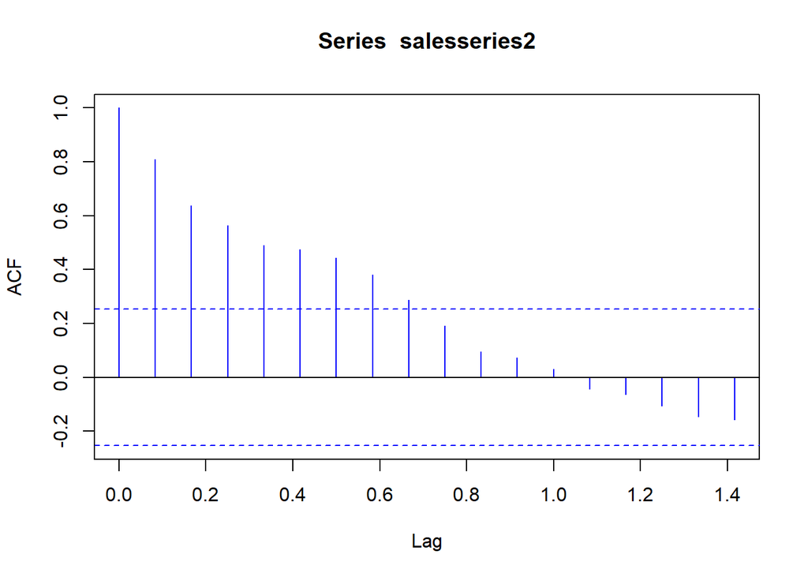

```r
acf(salesseries2,col="blue")
```

#### ACF plot shows a slow decay indicating non-stationarity

#### Dickey-Fuller test for product 2 time series

```r
library(urca)

df2<-ur.df(salesseries2, lag=0)
summary(df2)
```

```
###############################################
# Augmented Dickey-Fuller Test Unit Root Test #
###############################################

Test regression none


Call:
lm(formula = z.diff ~ z.lag.1 - 1)

Residuals:
    Min      1Q  Median      3Q     Max
-4.2474 -1.1471 -0.1161  1.2620  5.0273

Coefficients:
         Estimate Std. Error t value Pr(>|t|)
z.lag.1 0.0009495  0.0022746   0.417    0.678

Residual standard error: 2.112 on 58 degrees of freedom
Multiple R-squared:  0.002996,  Adjusted R-squared:  -0.01419
F-statistic: 0.1743 on 1 and 58 DF,  p-value: 0.6779


Value of test-statistic is: 0.4174

Critical values for test statistics:
     1pct  5pct 10pct
tau1 -2.6 -1.95 -1.61
```

#### Value of test statistic is greater than 5% critical value. Hence, Time series is non-stationary.

#### Dickey-Fuller test for 1st order differenced time series

```r
salesdiff2 <- diff(salesseries2,differences = 1)
summary(ur.df(salesdiff2,lags = 0))
```

```
###############################################
# Augmented Dickey-Fuller Test Unit Root Test #
###############################################

Test regression none


Call:
lm(formula = z.diff ~ z.lag.1 - 1)

Residuals:
    Min      1Q  Median      3Q     Max
-4.1177 -1.0583 -0.0909  1.3821  5.1249

Coefficients:
        Estimate Std. Error t value Pr(>|t|)
z.lag.1  -1.0166     0.1326  -7.667 2.46e-10 ***
---
Signif. codes:  0 '***' 0.001 '**' 0.01 '*' 0.05 '.' 0.1 ' ' 1

Residual standard error: 2.126 on 57 degrees of freedom
Multiple R-squared:  0.5077,    Adjusted R-squared:  0.4991
F-statistic: 58.78 on 1 and 57 DF,  p-value: 2.462e-10


Value of test-statistic is: -7.6668

Critical values for test statistics:
     1pct  5pct 10pct
tau1 -2.6 -1.95 -1.61
```

#### Value of test statistic is less than 5% critical value. Hence, Time series is stationary.

#### Automatic Model Identification and Parameter Estimation

```r
auto.arima(salesseries2,d=1,D=1,max.p=2,max.q=2,max.P=2,max.Q=2,
           trace=TRUE,ic="aic")
```

```
 ARIMA(2,1,2)(1,1,1)[12]                    : Inf
 ARIMA(0,1,0)(0,1,0)[12]                    : 236.3566
 ARIMA(1,1,0)(1,1,0)[12]                    : 229.7519
 ARIMA(0,1,1)(0,1,1)[12]                    : Inf
 ARIMA(1,1,0)(0,1,0)[12]                    : 238.3527
 ARIMA(1,1,0)(1,1,1)[12]                    : Inf
 ARIMA(1,1,0)(0,1,1)[12]                    : Inf
 ARIMA(0,1,0)(1,1,0)[12]                    : 227.793
 ARIMA(0,1,0)(1,1,1)[12]                    : Inf
 ARIMA(0,1,0)(0,1,1)[12]                    : Inf
 ARIMA(0,1,1)(1,1,0)[12]                    : 229.7371
 ARIMA(1,1,1)(1,1,0)[12]                    : Inf

 Best model: ARIMA(0,1,0)(1,1,0)[12]
```

```
Series: salesseries2
ARIMA(0,1,0)(1,1,0)[12]

Coefficients:
         sar1
      -0.4745
s.e.   0.1277

sigma^2 = 6.558:  log likelihood = -111.9
AIC=227.79   AICc=228.07   BIC=231.49
```

#### Store auto.arima in object salesmodel2 and then get coefficients

```r
salesmodel2<-auto.arima(salesseries2,d=1,D=1,max.p=2,max.q=2,max.P=2,max.Q=2,
           trace=TRUE,ic="aic")
```

```
 ARIMA(2,1,2)(1,1,1)[12]                    : Inf
 ARIMA(0,1,0)(0,1,0)[12]                    : 236.3566
 ARIMA(1,1,0)(1,1,0)[12]                    : 229.7519
 ARIMA(0,1,1)(0,1,1)[12]                    : Inf
 ARIMA(1,1,0)(0,1,0)[12]                    : 238.3527
 ARIMA(1,1,0)(1,1,1)[12]                    : Inf
 ARIMA(1,1,0)(0,1,1)[12]                    : Inf
 ARIMA(0,1,0)(1,1,0)[12]                    : 227.793
 ARIMA(0,1,0)(1,1,1)[12]                    : Inf
 ARIMA(0,1,0)(0,1,1)[12]                    : Inf
 ARIMA(0,1,1)(1,1,0)[12]                    : 229.7371
 ARIMA(1,1,1)(1,1,0)[12]                    : Inf

 Best model: ARIMA(0,1,0)(1,1,0)[12]
```

```r
coef(salesmodel2)
```

```
      sar1
-0.4744599
```

#### Check if residuals are white noise using Box-Pierce Test

```r
resi2<-residuals(salesmodel2)
Box.test(resi2)
```

```
    Box-Pierce test

data:  resi2
X-squared = 0.098411, df = 1, p-value = 0.7537
```

#### Since p-value is greater than 0.05, do not reject Ho. Hence it can be concluded that errors follow white noise process

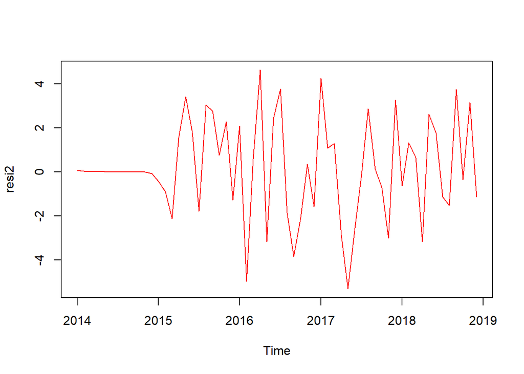

```r
plot(resi2,col="red")
```

#### Forecast product 2 sales for the next 3 months

```r
predict(salesmodel2,n.ahead=3)
```

```
$pred
          Jan      Feb      Mar
2019 129.1859 128.1560 127.9472

$se
          Jan      Feb      Mar
2019 2.560892 3.621648 4.435595
```

#### Analysis of Product 3

#### Create a time series object and visualize sales over 5 years

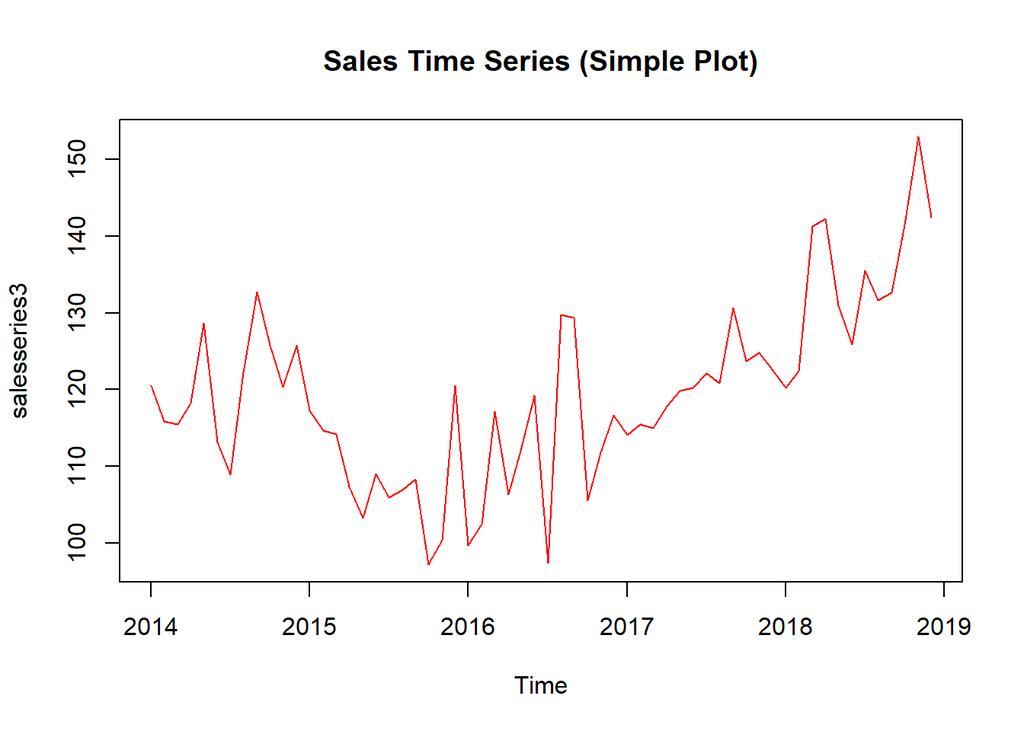

```r
salesseries3<-ts(salesdata$Product3,start=c(2014,1),end=c(2018,12),
                frequency=12)

plot(salesseries3,col="red",main="Sales Time Series (Simple Plot)")
```

#### Display ACF plot to check if product 3 sales forms stationary time series

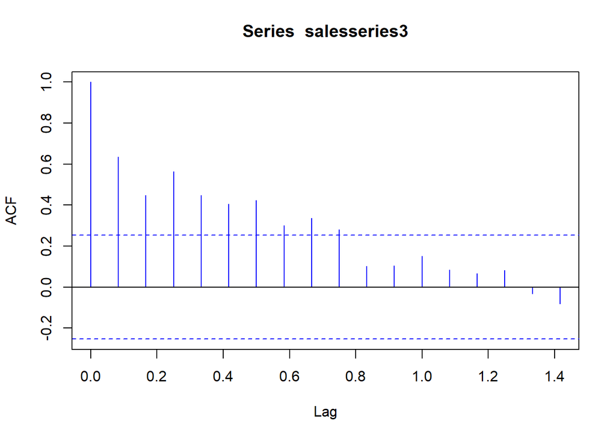

```r
acf(salesseries3,col="blue")
```

#### ACF plot shows a slow decay indicating non-stationarity

#### Dickey-Fuller test for product 3 time series

```r
library(urca)

df3<-ur.df(salesseries3, lag=0)
summary(df3)
```

```
###############################################
# Augmented Dickey-Fuller Test Unit Root Test #
###############################################

Test regression none


Call:
lm(formula = z.diff ~ z.lag.1 - 1)

Residuals:
    Min      1Q  Median      3Q     Max
-23.791  -4.480   0.941   5.556  32.282

Coefficients:
         Estimate Std. Error t value Pr(>|t|)
z.lag.1 8.204e-05  1.072e-02   0.008    0.994

Residual standard error: 9.853 on 58 degrees of freedom
Multiple R-squared:  1.009e-06, Adjusted R-squared:  -0.01724
F-statistic: 5.854e-05 on 1 and 58 DF,  p-value: 0.9939


Value of test-statistic is: 0.0077

Critical values for test statistics:
     1pct  5pct 10pct
tau1 -2.6 -1.95 -1.61
```

#### Value of test statistic is greater than 5% critical value. Hence, Time series is non-stationary.

#### Dickey-Fuller test for 1st order differenced time series

```r
salesdiff3 <- diff(salesseries3,differences = 1)
summary(ur.df(salesdiff3,lags = 0))
```

```
###############################################
# Augmented Dickey-Fuller Test Unit Root Test #
###############################################

Test regression none


Call:
lm(formula = z.diff ~ z.lag.1 - 1)

Residuals:
     Min       1Q   Median       3Q      Max
-23.9069  -4.9694  -0.2751   6.2641  25.3854

Coefficients:
        Estimate Std. Error t value Pr(>|t|)
z.lag.1  -1.3173     0.1267   -10.4 8.88e-15 ***
---
Signif. codes:  0 '***' 0.001 '**' 0.01 '*' 0.05 '.' 0.1 ' ' 1

Residual standard error: 9.415 on 57 degrees of freedom
Multiple R-squared:  0.6547,    Adjusted R-squared:  0.6486
F-statistic: 108.1 on 1 and 57 DF,  p-value: 8.885e-15


Value of test-statistic is: -10.396

Critical values for test statistics:
     1pct  5pct 10pct
tau1 -2.6 -1.95 -1.61
```

#### Value of test statistic is less than 5% critical value. Hence, Time series is stationary.

#### Automatic Model Identification and Parameter Estimation

```r
auto.arima(salesseries3,d=1,D=1,max.p=2,max.q=2,max.P=2,max.Q=2,
           trace=TRUE,ic="aic")
```

```
 ARIMA(2,1,2)(1,1,1)[12]                    : Inf
 ARIMA(0,1,0)(0,1,0)[12]                    : 374.8298
 ARIMA(1,1,0)(1,1,0)[12]                    : 367.1517
 ARIMA(0,1,1)(0,1,1)[12]                    : 356.1372
 ARIMA(0,1,1)(0,1,0)[12]                    : 362.3277
 ARIMA(0,1,1)(1,1,1)[12]                    : 358.0339
 ARIMA(0,1,1)(1,1,0)[12]                    : 358.388
 ARIMA(0,1,0)(0,1,1)[12]                    : 366.9472
 ARIMA(1,1,1)(0,1,1)[12]                    : 357.8424
 ARIMA(0,1,2)(0,1,1)[12]                    : 357.1796
 ARIMA(1,1,0)(0,1,1)[12]                    : 364.3365
 ARIMA(1,1,2)(0,1,1)[12]                    : 356.7408

 Best model: ARIMA(0,1,1)(0,1,1)[12]
```

```
Series: salesseries3
ARIMA(0,1,1)(0,1,1)[12]

Coefficients:
          ma1     sma1
      -0.6244  -0.6130
s.e.   0.1097   0.2638

sigma^2 = 92.45:  log likelihood = -175.07
AIC=356.14   AICc=356.7   BIC=361.69
```

#### Store auto.arima in object salesmodel3 and then get coefficients

```r
salesmodel3<-auto.arima(salesseries3,d=1,D=1,max.p=2,max.q=2,max.P=2,max.Q=2,
           trace=TRUE,ic="aic")
```

```
 ARIMA(2,1,2)(1,1,1)[12]                    : Inf
 ARIMA(0,1,0)(0,1,0)[12]                    : 374.8298
 ARIMA(1,1,0)(1,1,0)[12]                    : 367.1517
 ARIMA(0,1,1)(0,1,1)[12]                    : 356.1372
 ARIMA(0,1,1)(0,1,0)[12]                    : 362.3277
 ARIMA(0,1,1)(1,1,1)[12]                    : 358.0339
 ARIMA(0,1,1)(1,1,0)[12]                    : 358.388
 ARIMA(0,1,0)(0,1,1)[12]                    : 366.9472
 ARIMA(1,1,1)(0,1,1)[12]                    : 357.8424
 ARIMA(0,1,2)(0,1,1)[12]                    : 357.1796
 ARIMA(1,1,0)(0,1,1)[12]                    : 364.3365
 ARIMA(1,1,2)(0,1,1)[12]                    : 356.7408

 Best model: ARIMA(0,1,1)(0,1,1)[12]
```

```r
coef(salesmodel3)
```

```
       ma1       sma1
-0.6244316 -0.6129820
```

#### Check if residuals are white noise using Box-Pierce Test

```r
resi3<-residuals(salesmodel3)
Box.test(resi3)
```

```
    Box-Pierce test

data:  resi3
X-squared = 0.037754, df = 1, p-value = 0.8459
```

#### Since p-value is greater than 0.05, do not reject Ho. Hence it can be concluded that errors follow white noise process

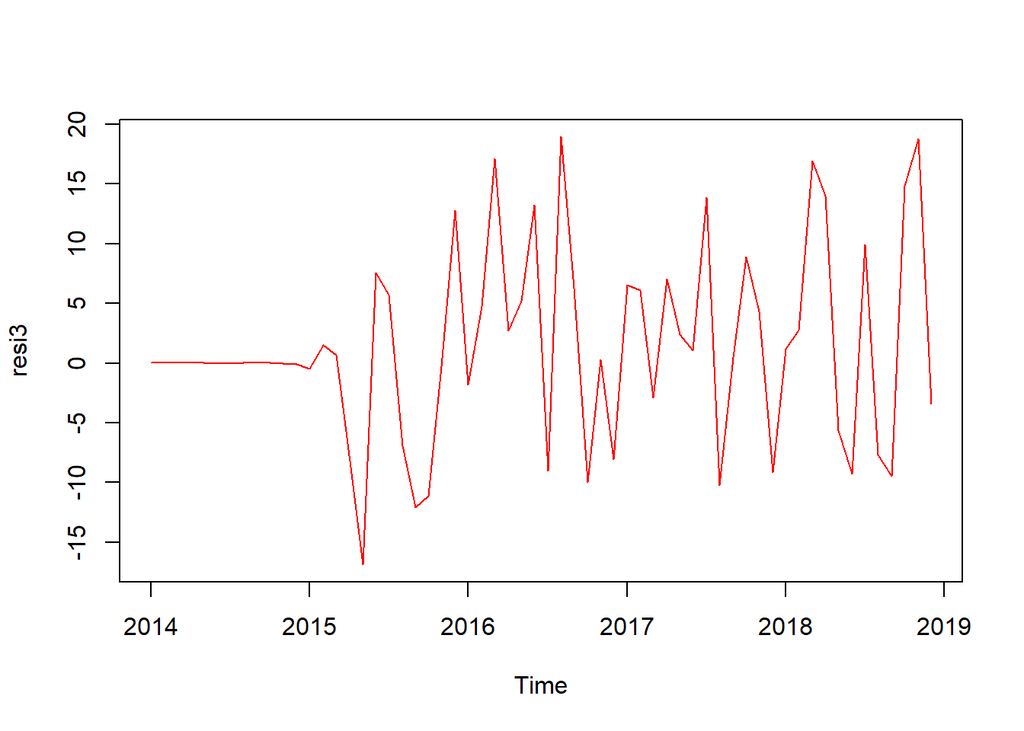

```r
plot(resi3,col="red")
```

#### Forecast product 3 sales for the next 3 months

```r
predict(salesmodel3,n.ahead=3)
```

```
$pred
          Jan      Feb      Mar
2019 138.2526 139.1981 148.7422

$se
           Jan       Feb       Mar
2019  9.661306 10.317094 10.933619
```

#### Table of forecasts

| Year | Month | Product1 | Product2 | Product3 |
| --- | --- | --- | --- | --- |
| 2019 | January | 142.6657 | 129.1859 | 138.2526 |
| 2019 | February | 142.1735 | 128.1560 | 139.1981 |
| 2019 | March | 142.7697 | 127.9472 | 148.7422 |